# therMizer Blog Vertical and Ontogenetic Migration

# Depth- and size-based temperature-dependent rates in mizer

Blog subhead: Temperature exposure varies by size and depth. Now you can include this mizer.

## Introduction

therMizer models the effects of temperature on individuals’ aerobic scope and metabolic rate using an approach that requires minimal parameterization. These temperature effects can vary based on both size and vertical habitat. This allows you to easily incorporate dynamic temperature-dependent rates into mizer, enabling simulations to include an important climate-related driver.

This post builds off the code presented in the initial therMizer blog post.

## Realm

`realm` refers to the vertical realms or depth strata which species inhabit and for which temperatures will be provided. These could be named something like *epipelagic*, *mesopelagic*, *surface*, *bottom*, whatever you want to call them. The important thing is that they match the realm names provided in the `ocean_temp` array that you’re using.

## Vertical migration

`vertical_migration` simulates the proportion of time that a given size of a given species spends in a given realm. It has the dimensions of `realm` $\times$ `sp` $\times$ `w`. Values can range from 0 to 1, and must sum to 1 across all realms for each species and size. If values sum to something other than one, it means that either a portion of time is unaccounted for (<1) or that time across realms is over-allocated (>1). Either way, you’ll be modeling something that cannot be replicated in the real ocean. You’ll also potentially end up with temperature effects that are outside the range of 0 - 1.

## Exposure

`exposure` links `vertical_migration` to `ocean_temp`. It has the dimensions of `realm` $\times$ `sp`. The values are 1 for the realms to which a species is exposed and 0 elsewhere. In theory, you could set all values to 1 and, so long as `vertical_migration` is constructed correctly, get the same results (because when multiplied by `exposure` the result would still be 0 for realms in which species spend no time). It’s up to you whether you’d like to go this route. However, you do need to ensure that the realm names and order match those used in `vertical_migration` and `ocean_temp`.

## Model input

In addition to species’ thermal tolerance ranges needed for therMizer, you’ll also need `vertical_migration` and `exposure` arrays. You’ll likely want to construct these outside mizer and read them in, similar to the interaction matrix. We’ll do a short example below, though, to get you started.

## A simple simulation

Let’s do a simple simulation with two fictional fish species. We’ll need to invent some parameters for them:

```r
library(mizer)

species_params = data.frame(species = c("speciesA", "speciesB"), w_inf = c(500, 5000), k_vb = c(0.8, 0.3), w_min = c(0.001, 0.001), w_mat = c(5, 50), beta = c(1000,100), sigma = c(3,3))
species_params$interaction_resource <- c(1,0.5)
params_noTemp <- newMultispeciesParams(species_params, no_w = 200, kappa = 0.0001) |>
    steady(tol = 0.001)
params_Temp <- newMultispeciesParams(species_params, no_w = 200, kappa = 0.0001) |>
    steady(tol = 0.001)
```

Add their hypothetical thermal tolerance limits:

```r
species_params(params_Temp)$temp_min <- c(-5, 10)
species_params(params_Temp)$temp_max <- c(5, 20)
```

Now we can set up the `vertical_migration array`. We’ll assume one species stays in the upper 50 m of the water column until it moves to the bottom at maturity and that all sizes of the other species undergo diel vertical migration (DVM). This will give us four realms.

```r
realm_names <- c("upper50m","bottom","DVM_day","DVM_night")
species_names <- as.character(params_Temp@species_params$species)
sizes <- params_Temp@w

# Create the vertical migration array and fill it
vertical_migration_array <- array(0, dim = (c(length(realm_names), length(species_names), length(sizes))), dimnames = list(realm = realm_names, sp = species_names, w = signif(sizes,3))) # realm x species x size

upp <- which(realm_names == "upper50m") # 0 - 50m average
btm <- which(realm_names == "bottom") # sea floor
DVMd <- which(realm_names == "DVM_day") # 200 - 500m average
DVMn <- which(realm_names == "DVM_night") # 0 - 100m average

# Set all sizes below w_mat for speciesA to "upper50m" and all sizes above w_mat to "bottom
spA <- which(species_names == "speciesA")
vertical_migration_array[upp, spA, sizes < params_Temp@species_params$w_mat[spA]] <- 1
vertical_migration_array[btm, spA, sizes >= params_Temp@species_params$w_mat[spA]] <- 1

# Have speciesB split its time equally using DVM
spB <- which(species_names == "speciesB")
vertical_migration_array[DVMd, spB, ] <- 0.5
vertical_migration_array[DVMn, spB, ] <- 0.5

# And check that all filled size classes sum to 1, no more and no less
for (s in seq(1,length(species_names),1)) {
    if (!all(apply(vertical_migration_array[ , s, ],2,sum) == 1)) {
        stop(paste("Your realm allocations for ", species_names[s], " don't sum to 1 for all sizes.
        Their time in a given realm is either over- or under-allocated.", sep = ""))
    }
}

other_params(params_Temp)$vertical_migration <- vertical_migration_array
```

We can also set up the `exposure` array.

```r
exposure_array <- array(0, dim = (c(length(realm_names), length(species_names))), dimnames = list(realm = realm_names, sp = species_names)) # realm x species

for (r in seq(1,length(realm_names),1)) {
    for (s in seq(1,length(species_names),1)) {
        if (any(vertical_migration_array[r,s,] > 0)) {
            exposure_array[r,s] = 1
        }
    }
}

other_params(params_Temp)$exposure <- exposure_array
```

Now we need to create the temperature for each realm.

```r
# Create temperature array and fill it
times <- 0:500
ocean_temp_array <- array(NA, dim = c(length(times), length(realm_names)), dimnames = list(time = times, realm = realm_names))
temp_inc <- 0
for (i in 1:501) {
  ocean_temp_array[i,] <- c(0 + temp_inc, -5 + temp_inc, 11 + temp_inc, 15 + temp_inc)
  temp_inc <- temp_inc + 0.01
}

other_params(params_Temp)$ocean_temp <- ocean_temp_array
```

```r
other_params(params_Temp)
```

[output not shown]

[output cut: 512 more lines]

[output not shown]

[figure not shown]

Let’s see what a simulation looks like.

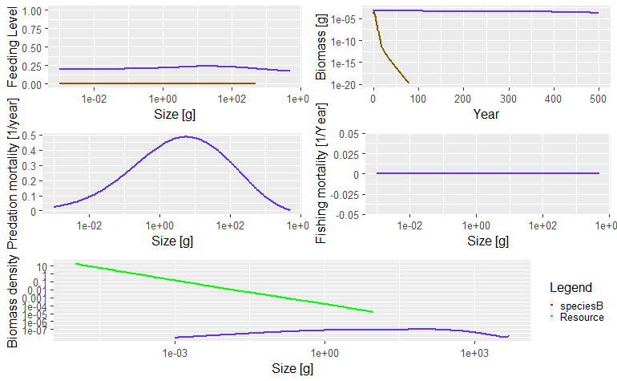

```r
sim_Temp <- project(params_Temp, t_max = 500, effort = 0)
plot(sim_Temp)
```

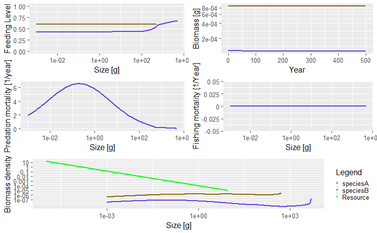

```r
sim_noTemp <- project(params_noTemp, t_max = 500, effort = 0)
plot(sim_noTemp)
```

## Adapting this for a data-based simulation

You’re likely going to want to do simulations based on real species and real temperature observations or projections. This is straightforward to do. When you prepare your species parameters, add `temp_min` and `temp_max` columns for each species. You’ll also need to prepare an `ocean_temp` input with dimensions that match those of `time` and `realm`, a `vertical_migration` array, and an `exposure` array.

## Acknowledgements

This blog post was compiled with mizer version 2.3.0.1 and R version 4.2.1.